# A Visual Data Story About Social Media Advertising

## Comparing how relevant advertisements are on different social media platforms

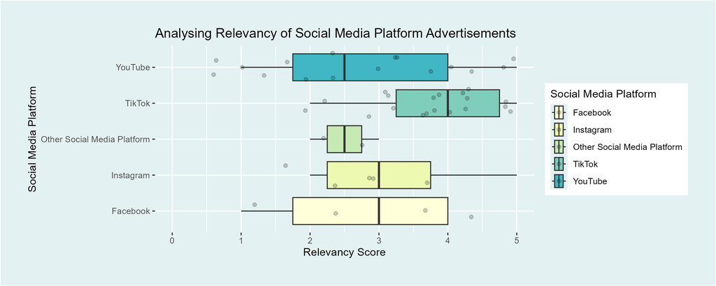

Box plot comparing relevance of advertisements on various platforms

This plot shows the relevancy of advertisements on various social media platforms. This is done by using box and whisker plots. These plots show the low, lower quartile, median, upper quartile, and high relevancy scores for each social media platform. From this, we can analyse the plot and can make assumptions regarding the data. For example, based on the image above we can say that TikTok has the highest median relevancy score when compared to other platforms. Whereas, Youtube and Other Social Media Platforms (various platforms which were not explicitly listed on the form, but entered by users and grouped into an ‘other’ category) draw with the lowest median relevancy score when compared to other platforms. This data is insightful as we are able to draw connections to the results. We can analyse how effective targeted advertising is on various platforms. It can also show which platforms could be more effective to advertise on.

## TikTok versus The Rest

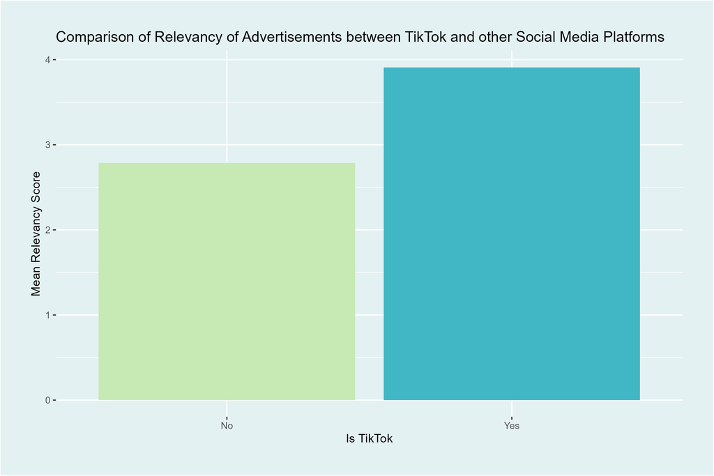

Column plot comparing mean relevancy of TikTok and other social media platforms

This plot compares the mean relevancy score of advertisements on TikTok and the mean relevancy score of advertisements on all other social media platforms. This is shown on a column graph. The plot on the image above shows that TikTok has a much higher mean relevancy score of advertisements when compared to the mean relevancy score of advertisements on all other social media platforms. It is possible that TikTok has a much more advanced and/or more successful advertisement targeting algorithm. This could explain why TikTok’s mean relevancy score is higher than the mean of other platforms.

## So When Should You Advertise?

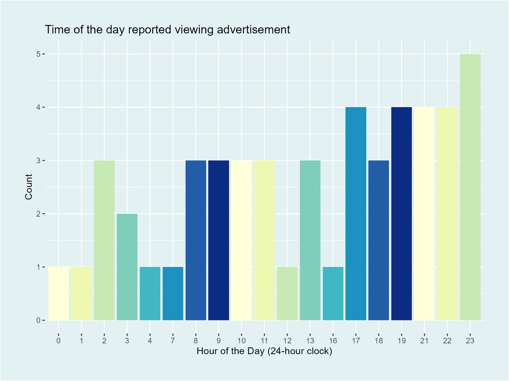

Bar graph showing times of day when advertisement seen by respondent

This plot shows all the reported viewing times of advertisements. This is shown using a bar graph which shows the different hours on the x-axis and the count on the y-axis. This data can be used to show which times of a day respondents view advertisements. In turn, this can show advertisers which times would be most beneficial to advertise for maximum reach.